# Machine Learning Project

## random forest

```r
set.seed(5074491)
starttime<-Sys.time()
# tr_c<-trainControl(method='repeatedcv',number=20,repeats=5,allowParallel=TRUE)
tr_c<-trainControl(method='cv',number=10,allowParallel=TRUE)

# 20 fold cross validation, repeated 5 times
# can also select 'oob' for out of bag
# model_ranger_nopca<-train(classe~.,data=slim2,method='ranger',trControl=tr_c)
model_ranger<-train(classe ~ .  ,data=slimtr,method='ranger',trControl=tr_c,tuneGrid = expand.grid(mtry= c(5,10,20)),importance='impurity')
endtime<-Sys.time()
endtime - starttime
```

```
## Time difference of 2.738303 mins
```

output model stuff

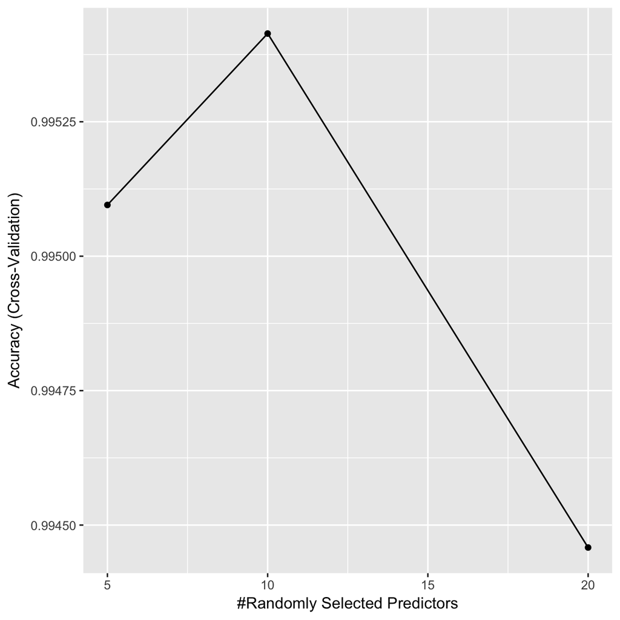

```r
ggplot(model_ranger)
```

```r
model_ranger
```

```
## Random Forest
##
## 15699 samples
##    52 predictor
##     5 classes: 'A', 'B', 'C', 'D', 'E'
##
## No pre-processing
## Resampling: Cross-Validated (10 fold)
## Summary of sample sizes: 14129, 14129, 14130, 14128, 14129, 14130, ...
## Resampling results across tuning parameters:
##
##   mtry  Accuracy   Kappa
##    5    0.9950953  0.9937957
##   10    0.9954140  0.9941990
##   20    0.9944582  0.9929902
##
## Accuracy was used to select the optimal model using  the largest value.
## The final value used for the model was mtry = 10.
```

```r
model_ranger$finalModel
```

```
## Ranger result
##
## Call:
##  ranger(.outcome ~ ., data = x, mtry = param$mtry, write.forest = TRUE,      probability = classProbs, ...)
##
## Type:                             Classification
## Number of trees:                  500
## Sample size:                      15699
## Number of independent variables:  52
## Mtry:                             10
## Target node size:                 1
## Variable importance mode:         impurity
## OOB prediction error:             0.43 %
```

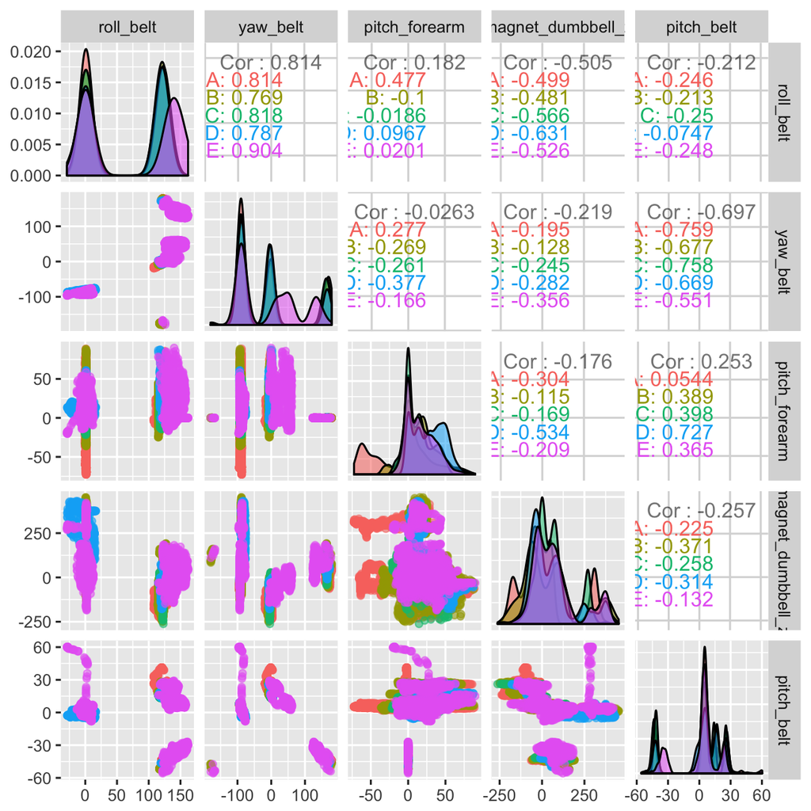

```r
# tr_c<-trainControl(method="cv",preProcOptions = list(thresh = 0.8))
# model_glm<-train(classe~.,data=slimmed,method='glm',family='binomial',train_control=tr_c,preProcess=c('pca','knnImpute'))
# summary(model_glm)
moose<-varImp(model_ranger)
mostimport <- order(moose$importance$Overall,decreasing=TRUE)
h<-ggpairs(data=slimtr,columns=mostimport[1:5],mapping=ggplot2::aes(colour = classe,alpha=0.1))
print(h)
```

```r
# confusionMatrix
rangerpred<-predict(model_ranger,newdata=slimval)
confusionMatrix(data=rangerpred,reference=slimval$classe)
```

```
## Confusion Matrix and Statistics
##
##           Reference
## Prediction    A    B    C    D    E
##          A 1116    1    0    0    0
##          B    0  758    1    0    0
##          C    0    0  682    4    0
##          D    0    0    1  638    1
##          E    0    0    0    1  720
##
## Overall Statistics
##
##                Accuracy : 0.9977
##                  95% CI : (0.9956, 0.999)
##     No Information Rate : 0.2845
##     P-Value [Acc > NIR] : < 2.2e-16
##
##                   Kappa : 0.9971
##  Mcnemar's Test P-Value : NA
##
## Statistics by Class:
##
##                      Class: A Class: B Class: C Class: D Class: E
## Sensitivity            1.0000   0.9987   0.9971   0.9922   0.9986
## Specificity            0.9996   0.9997   0.9988   0.9994   0.9997
## Pos Pred Value         0.9991   0.9987   0.9942   0.9969   0.9986
## Neg Pred Value         1.0000   0.9997   0.9994   0.9985   0.9997
## Prevalence             0.2845   0.1935   0.1744   0.1639   0.1838
## Detection Rate         0.2845   0.1932   0.1738   0.1626   0.1835
## Detection Prevalence   0.2847   0.1935   0.1749   0.1631   0.1838
## Balanced Accuracy      0.9998   0.9992   0.9979   0.9958   0.9992
```

A second random forest, this time using repeated cross validation, and maybe some more variable samplings

```r
set.seed(5074491)
starttime<-Sys.time()
# tr_c<-trainControl(method='repeatedcv',number=20,repeats=5,allowParallel=TRUE)
tr_c<-trainControl(method='repeatedcv',number=10,repeats=3,allowParallel=TRUE)

# 20 fold cross validation, repeated 5 times
# can also select 'oob' for out of bag
# model_ranger_nopca<-train(classe~.,data=slim2,method='ranger',trControl=tr_c)
model_ranger2<-train(classe ~ .  ,data=slimtr,method='ranger',trControl=tr_c,tuneGrid = expand.grid(mtry= c(2,10,30)),importance='impurity')
endtime<-Sys.time()
endtime - starttime
```

```
## Time difference of 9.008132 mins
```

ranger2 stuff

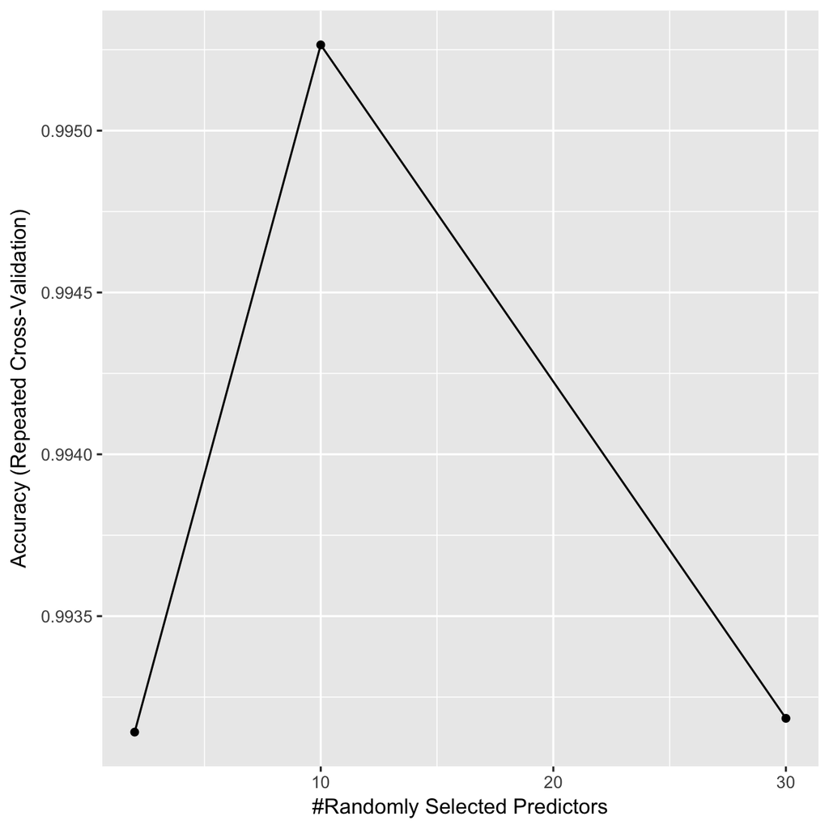

```r
ggplot(model_ranger2)
```

```r
model_ranger2
```

```
## Random Forest
##
## 15699 samples
##    52 predictor
##     5 classes: 'A', 'B', 'C', 'D', 'E'
##
## No pre-processing
## Resampling: Cross-Validated (10 fold, repeated 3 times)
## Summary of sample sizes: 14129, 14129, 14130, 14128, 14129, 14130, ...
## Resampling results across tuning parameters:
##
##   mtry  Accuracy   Kappa
##    2    0.9931417  0.9913236
##   10    0.9952649  0.9940104
##   30    0.9931842  0.9913785
##
## Accuracy was used to select the optimal model using  the largest value.
## The final value used for the model was mtry = 10.
```

```r
model_ranger2$finalModel
```

```
## Ranger result
##
## Call:
##  ranger(.outcome ~ ., data = x, mtry = param$mtry, write.forest = TRUE,      probability = classProbs, ...)
##
## Type:                             Classification
## Number of trees:                  500
## Sample size:                      15699
## Number of independent variables:  52
## Mtry:                             10
## Target node size:                 1
## Variable importance mode:         impurity
## OOB prediction error:             0.42 %
```

```r
# tr_c<-trainControl(method="cv",preProcOptions = list(thresh = 0.8))
# model_glm<-train(classe~.,data=slimmed,method='glm',family='binomial',train_control=tr_c,preProcess=c('pca','knnImpute'))
# summary(model_glm)
varImp(model_ranger2)
```

```
## ranger variable importance
##
##   only 20 most important variables shown (out of 52)
##
##                      Overall
## roll_belt             100.00
## yaw_belt               65.06
## pitch_forearm          59.39
## magnet_dumbbell_z      52.26
## magnet_dumbbell_y      48.31
## pitch_belt             48.14
## roll_forearm           43.51
## magnet_dumbbell_x      29.87
## roll_dumbbell          25.60
## accel_dumbbell_y       25.51
## accel_belt_z           24.51
## magnet_belt_y          22.51
## magnet_belt_z          22.47
## accel_dumbbell_z       19.06
## accel_forearm_x        18.76
## gyros_belt_z           17.75
## roll_arm               17.21
## magnet_forearm_z       17.03
## total_accel_dumbbell   14.63
## magnet_arm_x           13.71
```

```r
# confusionMatrix
ranger2pred<-predict(model_ranger2,newdata=slimval)
confusionMatrix(data=ranger2pred,reference=slimval$classe)
```

```
## Confusion Matrix and Statistics
##
##           Reference
## Prediction    A    B    C    D    E
##          A 1116    1    0    0    0
##          B    0  758    1    0    0
##          C    0    0  682    4    0
##          D    0    0    1  638    1
##          E    0    0    0    1  720
##
## Overall Statistics
##
##                Accuracy : 0.9977
##                  95% CI : (0.9956, 0.999)
##     No Information Rate : 0.2845
##     P-Value [Acc > NIR] : < 2.2e-16
##
##                   Kappa : 0.9971
##  Mcnemar's Test P-Value : NA
##
## Statistics by Class:
##
##                      Class: A Class: B Class: C Class: D Class: E
## Sensitivity            1.0000   0.9987   0.9971   0.9922   0.9986
## Specificity            0.9996   0.9997   0.9988   0.9994   0.9997
## Pos Pred Value         0.9991   0.9987   0.9942   0.9969   0.9986
## Neg Pred Value         1.0000   0.9997   0.9994   0.9985   0.9997
## Prevalence             0.2845   0.1935   0.1744   0.1639   0.1838
## Detection Rate         0.2845   0.1932   0.1738   0.1626   0.1835
## Detection Prevalence   0.2847   0.1935   0.1749   0.1631   0.1838
## Balanced Accuracy      0.9998   0.9992   0.9979   0.9958   0.9992
```

ranger3, random forest with pca

First, preprocess the training set to get an idea of how many components to use. We will want to do the actual pca preprocessing within the train method, but want to know how many variables will be present (specify pcaComps). This is needed for the mtry grid used by train (can try a random sample of 40 variables if there are only 12 after pca).

```r
set.seed(5074491)
starttime<-Sys.time()
preproc<-preProcess(slimtr[-53],method='pca',thresh=0.95)
preproc
```

```
## Created from 15699 samples and 52 variables
##
## Pre-processing:
##   - centered (52)
##   - ignored (0)
##   - principal component signal extraction (52)
##   - scaled (52)
##
## PCA needed 25 components to capture 95 percent of the variance
```

```r
preproc<-preProcess(slimtr[-53],method='pca',thresh=0.90)
preproc
```

```
## Created from 15699 samples and 52 variables
##
## Pre-processing:
##   - centered (52)
##   - ignored (0)
##   - principal component signal extraction (52)
##   - scaled (52)
##
## PCA needed 18 components to capture 90 percent of the variance
```

```r
preproc<-preProcess(slimtr[-53],method='pca',thresh=0.85)
preproc
```

```
## Created from 15699 samples and 52 variables
##
## Pre-processing:
##   - centered (52)
##   - ignored (0)
##   - principal component signal extraction (52)
##   - scaled (52)
##
## PCA needed 15 components to capture 85 percent of the variance
```

```r
endtime<-Sys.time()
endtime - starttime
```

```
## Time difference of 1.123816 secs
```

will use 25 components (for now)

```r
set.seed(5074491)
starttime<-Sys.time()
# tr_c<-trainControl(method='repeatedcv',number=20,repeats=5,allowParallel=TRUE)
tr_c<-trainControl(method='repeatedcv',number=10,repeats=3,allowParallel=TRUE,preProcOptions = list(pcaComp = 25))
model_ranger3<-train(classe ~ .  ,data=slimtr,method='ranger',trControl=tr_c,tuneGrid = expand.grid(mtry= c(2,4,8,10)),importance='impurity',preProcess='pca')
endtime<-Sys.time()
endtime - starttime
```

```
## Time difference of 23.47712 mins
```

ranger3 stuff

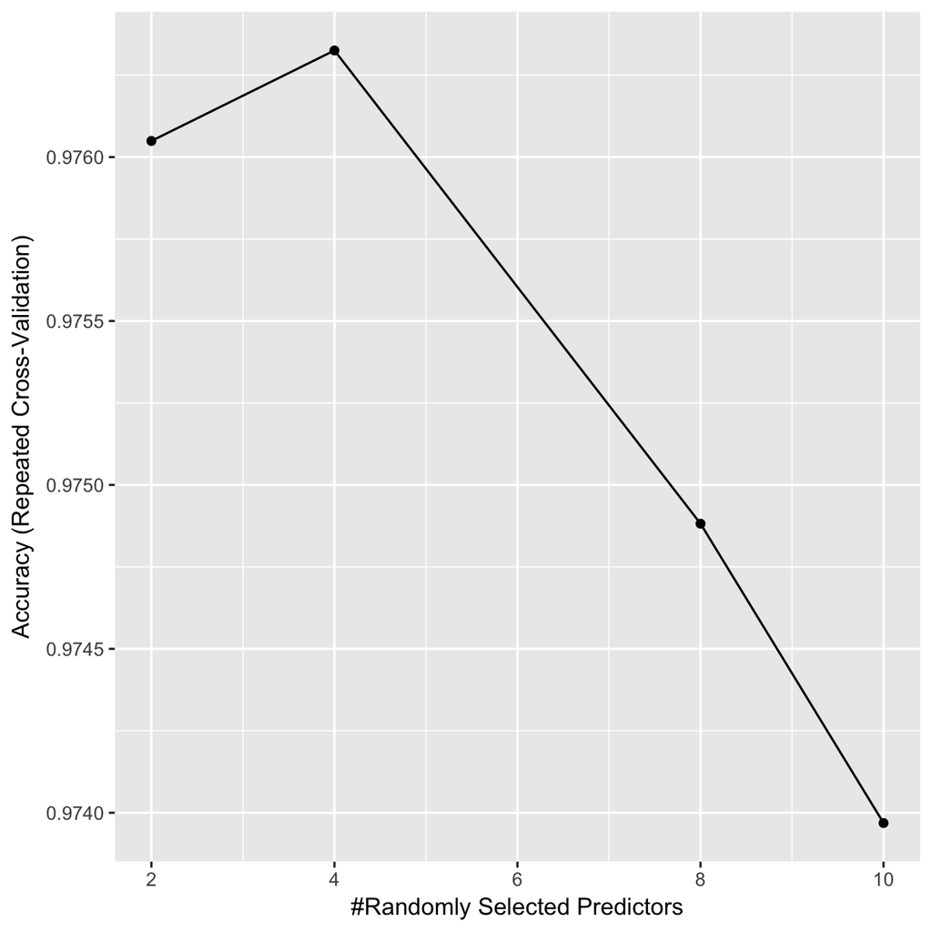

```r
ggplot(model_ranger3)
```

```r
model_ranger3
```

```
## Random Forest
##
## 15699 samples
##    52 predictor
##     5 classes: 'A', 'B', 'C', 'D', 'E'
##
## Pre-processing: principal component signal extraction (52), centered
##  (52), scaled (52)
## Resampling: Cross-Validated (10 fold, repeated 3 times)
## Summary of sample sizes: 14129, 14129, 14130, 14128, 14129, 14130, ...
## Resampling results across tuning parameters:
##
##   mtry  Accuracy   Kappa
##    2    0.9760492  0.9697007
##    4    0.9763253  0.9700508
##    8    0.9748817  0.9682261
##   10    0.9739686  0.9670705
##
## Accuracy was used to select the optimal model using  the largest value.
## The final value used for the model was mtry = 4.
```

```r
model_ranger3$finalModel
```

```
## Ranger result
##
## Call:
##  ranger(.outcome ~ ., data = x, mtry = param$mtry, write.forest = TRUE,      probability = classProbs, ...)
##
## Type:                             Classification
## Number of trees:                  500
## Sample size:                      15699
## Number of independent variables:  25
## Mtry:                             4
## Target node size:                 1
## Variable importance mode:         impurity
## OOB prediction error:             2.16 %
```

```r
#confusionMatrix
# confusionMatrix
ranger3pred<-predict(model_ranger3,newdata=slimval)
confusionMatrix(data=ranger3pred,reference=slimval$classe)
```

```
## Confusion Matrix and Statistics
##
##           Reference
## Prediction    A    B    C    D    E
##          A 1113   16    1    2    0
##          B    2  735    6    1    3
##          C    1    6  671   18    1
##          D    0    0    6  622    2
##          E    0    2    0    0  715
##
## Overall Statistics
##
##                Accuracy : 0.9829
##                  95% CI : (0.9784, 0.9867)
##     No Information Rate : 0.2845
##     P-Value [Acc > NIR] : < 2.2e-16
##
##                   Kappa : 0.9784
##  Mcnemar's Test P-Value : NA
##
## Statistics by Class:
##
##                      Class: A Class: B Class: C Class: D Class: E
## Sensitivity            0.9973   0.9684   0.9810   0.9673   0.9917
## Specificity            0.9932   0.9962   0.9920   0.9976   0.9994
## Pos Pred Value         0.9832   0.9839   0.9627   0.9873   0.9972
## Neg Pred Value         0.9989   0.9924   0.9960   0.9936   0.9981
## Prevalence             0.2845   0.1935   0.1744   0.1639   0.1838
## Detection Rate         0.2837   0.1874   0.1710   0.1586   0.1823
## Detection Prevalence   0.2886   0.1904   0.1777   0.1606   0.1828
## Balanced Accuracy      0.9953   0.9823   0.9865   0.9825   0.9955
```

```r
# tr_c<-trainControl(method="cv",preProcOptions = list(thresh = 0.8))
# model_glm<-train(classe~.,data=slimmed,method='glm',family='binomial',train_control=tr_c,preProcess=c('pca','knnImpute'))
# summary(model_glm)
varImp(model_ranger3)
```

```
## ranger variable importance
##
##   only 20 most important variables shown (out of 25)
##
##      Overall
## PC8   100.00
## PC12   79.87
## PC1    77.00
## PC14   74.58
## PC5    65.99
## PC3    59.48
## PC9    58.94
## PC15   54.85
## PC2    47.63
## PC6    45.14
## PC16   40.46
## PC22   40.38
## PC17   39.50
## PC7    35.82
## PC21   34.32
## PC10   34.17
## PC13   31.30
## PC4    29.40
## PC20   26.30
## PC11   24.80
```

## Ensemble Learning

first, set up a seperate validation set. Pull this from training.

Use an odd number of models. Right now we have a few random forests (with and without PCA) and a basic decision tree. Maybe add a glm (can we do this for classification?) and an svm. look through caret if we want more